# Assignment 1 - The tidyverse

Aditya Narayan Rai + adityanarayan-rai

September 26, 2023 | 02:02:57 | CEST

```r
# To work on this dataset, I am going to use the following packages:
library(tidyverse)
library(ggplot2)
library(legislatoR)
```

### Getting started with the Comparative Legislators Database

The Comparative Legislators Database (CLD) includes political, sociodemographic, career, online presence, public attention, and visual information for over 45,000 contemporary and historical politicians from ten countries (see the [corresponding article](https://www.cambridge.org/core/journals/british-journal-of-political-science/article/comparative-legislators-database/D28BB58A8B2C08C8593DB741F42C18B2) for more information). It can be accessed via `legislatoR` - an R package that is available on both [CRAN](https://cran.r-project.org/web/packages/legislatoR/index.html) and [GitHub](https://github.com/saschagobel/legislatoR).

Before you start with the following tasks, skim the tutorial to make yourself familiar with the database. You find it [here](https://cran.r-project.org/web/packages/legislatoR/vignettes/legislatoR.html).

For the following tasks, you will work with ONE of the legislatures. The legislature you’ll work with depends on your first name:

| Your first name starts with… | Legislature | Code |
| --- | --- | --- |
| A-C | Austrian Nationalrat | `aut` |
| D-F | Canadian House of Commons | `can` |
| G-I | Czech Poslanecka Snemovna | `cze` |
| J-L | Spanish Congreso de los Diputados | `esp` |
| M-O | French Assemblée | `fra` |
| P-R | German Bundestag | `deu` |
| S-U | Irish Dail | `irl` |
| V-X | UK House of Commons | `gbr` |
| Y-Z | US House of Representatives | `usa_house` |

The following tasks will be based on data from the `core` and `political` tables of the database.

### Task 1 - Descriptives

1. What’s the overall share of female legislators in the entire dataset?

```r
aut <- get_core(legislature = "aut") #import the Austria Legislator dataset
#str(aut) #checking the structure of the dataset
#dim(aut) #checking the dimensions of the dataset
#names(aut) #checking the variables of the dataset

total_legislators <- nrow(aut) #calculate the total number of legislators
female_legislators <- sum(aut$sex == "female", na.rm = TRUE) #calculate total number of female legislators

overall_female_share <- (female_legislators / total_legislators) * 100 #calculate the overall share of female legislators

#print the result and limit the decimal to three places
cat("The overall share of female legislators in the dataset is:", sprintf("%.3f", overall_female_share), "%\n") #note: I used Google (stackoverflow) to learn about this print function and incorporated it here
```

```
The overall share of female legislators in the dataset is: 18.617 %
```

2. How many (both in absolute and relative terms) legislators died in the same place they were born in?

```r
#first calculate the absolute count of legislators who died in the same place they were born in using filter
absolute_count <- aut |>
  filter(!is.na(birthplace) & !is.na(deathplace) & birthplace == deathplace) |>
  nrow()

#now calculate the relative count (%) of legislators who died in the same place they were born in
relative_count <- (absolute_count / total_legislators) * 100 #remember we already have total_legislators from the previous question

#print both absolute and relative
cat("Absolute count of legislators who died in the same place they were born in:", absolute_count, "\n")
```

```
Absolute count of legislators who died in the same place they were born in: 253
```

```r
cat("Relative count (%) of legislators who died in the same place they were born in:", sprintf("%.3f", relative_count), "%\n") #note: I used Google (stackoverflow) to learn about this print function and incorporated it here
```

```
Relative count (%) of legislators who died in the same place they were born in: 13.157 %
```

3. Create a new variable `age_at_death` that reports the age at which legislators died. Then, plot the distribution of that variable for the entire dataset.

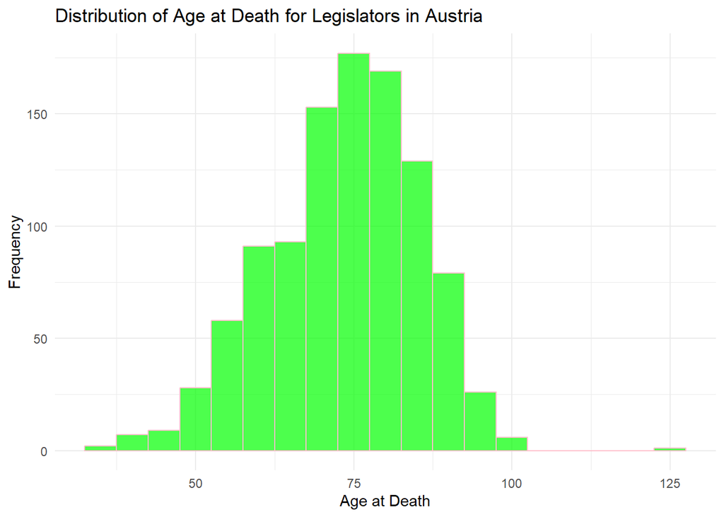

```r
#filter the rows with missing values in both the death and birth variables
aut <- aut |>
  filter(!is.na(birth) & !is.na(death)) |>
  #now calculate the age at death using the mutate function
  mutate(age_at_death = as.integer(difftime(as.Date(death, format = "%Y-%m-%d"), as.Date(birth, format = "%Y-%m-%d"), units = "days") / 365.25)) #dividing by 365.25 means accounting for leap years
#note: I read about the use of the difftime, as.Date, and format = functions through Google search and incorporated it here

#now plot the distribution of Age at Death using ggplot
aut |>
  ggplot(aes(x = age_at_death)) +
  geom_histogram(binwidth = 5, fill = "green", color = "pink", alpha = 0.7) +
  labs(
    title = "Distribution of Age at Death for Legislators in Austria",
    x = "Age at Death",
    y = "Frequency"
  ) +
  theme_minimal() #note: I used Google (stackoverflow) to learn about the aesthetics aspects of the graph and incorporated it here
```

4. What is the most frequent birthday in your sample (e.g., “January 15”)?

```r
#first filter out the rows with missing birth dates
aut <- aut |>
  filter(!is.na(birth))

#now extract the day and month from the birth column using mutate function
aut <- aut |>
  mutate(birth_date = as.Date(birth, format = "%Y-%m-%d"),
         birth_month_day = format(birth_date, "%B %d")) #note: I read about the use of the difftime, as.Date, and 'format =' functions through Google search and incorporated it here

#now count the occurances of each birthday using count function
birthday_counts <- aut |>
  count(birth_month_day, sort = TRUE)

#calculate most frequent birthday
most_frequent_birthday <- birthday_counts[1, "birth_month_day"]

#let's check the result now
cat("The most frequent birthday in the sample is:", most_frequent_birthday, "\n")
```

```
The most frequent birthday in the sample is: January 01
```

5. Generate a table that provides the 5 legislators with the longest names (in terms of number of characters, ignoring whitespace).

```r
#first filter rows with missing values
aut <- aut %>%
  filter(!is.na(name))

#create a variable named name_length to store the length of names without whitespace using mutate function
aut <- aut %>%
  mutate(name_length = nchar(gsub(" ", "", name))) #note: I read about the 'nchar' and 'gsub' functions and their uses using the Google search and incorporated it here

#now arrange the new variable in descending order
aut <- aut %>%
  arrange(desc(name_length))

#now select top 5 longest names and store it in a new variable
top_longest_names <- aut %>%
  head(5)

#print the top 5 longest names
print(top_longest_names)
```

```
  country  pageid wikidataid                       wikititle
1     AUT 9806509  Q28871872 Johannes_Schauer-Schoberlechner
2     AUT 3463222   Q1670894   Katharina_Cortolezis-Schlager
3     AUT 5892495   Q1358381     Ernst_Grundemann-Falkenberg
4     AUT 3073583   Q1651374     Ludwig_August_Bretschneider
5     AUT 9116250  Q21820643        Rudolf_Kristofics-Binder
                             name    sex ethnicity religion      birth
1 Schauer-Schoberlechner Johannes   male      <NA>     <NA> 1884-12-04
2   Cortolezis-Schlager Katharina female      <NA>     <NA> 1960-05-17
3     Grundemann-Falkenberg Ernst   male      <NA>     <NA> 1903-08-01
4     Bretschneider Ludwig August   male     white     <NA> 1860-08-22
5        Kristofics-Binder Rudolf   male      <NA>     <NA> 1896-01-24
       death        birthplace        deathplace age_at_death birth_date
1 1955-09-02              <NA>              <NA>           70 1884-12-04
2 2015-07-20 47.06667,15.43333 48.20833,16.37306           55 1960-05-17
3 1987-09-19 48.54639,14.38361 48.54639,14.38361           84 1903-08-01
4 1929-08-04 48.20833,16.37306 48.20833,16.37306           68 1860-08-22
5 1969-10-22 46.38333,16.43333 48.20833,16.37306           73 1896-01-24
  birth_month_day name_length
1     December 04          30
2          May 17          28
3       August 01          26
4       August 22          25
5      January 24          23
```

### Task 2 - Exploring trends in the data

1. Using data from all sessions, provide a plot that shows the share of female legislators by session!

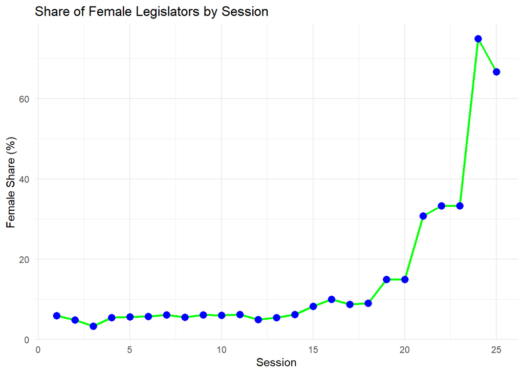

```r
#import the political dataset for Austria
aut_political <- get_political("aut")
#names(aut_political) #check names of the political dataset
#names(aut) #check names of the core dataset

#both the datasets have 'pageid' as the common variable. we will use that to merge both the datasets
merged_aut <- merge(aut, aut_political, by = "pageid")

#now let's calculate the share of female legislators by session
female_share_by_session <- merged_aut |>
  group_by(session) |>
  summarize(female_share = mean(sex == "female", na.rm = TRUE) * 100) |>
  arrange(session) #note: I used Google search to understand the combination of these three functions and saw an example of the same in stackoverflow

#let's plot the share of female legislators by session. Will use a line graph
ggplot(female_share_by_session, aes(x = session, y = female_share, group = 1)) +
  geom_line(color = "green", size = 1) +
  geom_point(color = "blue", size = 3) +
  labs(
    title = "Share of Female Legislators by Session",
    x = "Session",
    y = "Female Share (%)"
  ) +
  theme_minimal() #note: I used Google search for geom_line and geom_point and incorporated them here
```

2. Explore another relation of variables in the dataset. Your analysis should (i) use data from both the `core` and the `political` table and (ii) feature data from several sessions. Also, offer a brief description and interpretation of your findings!

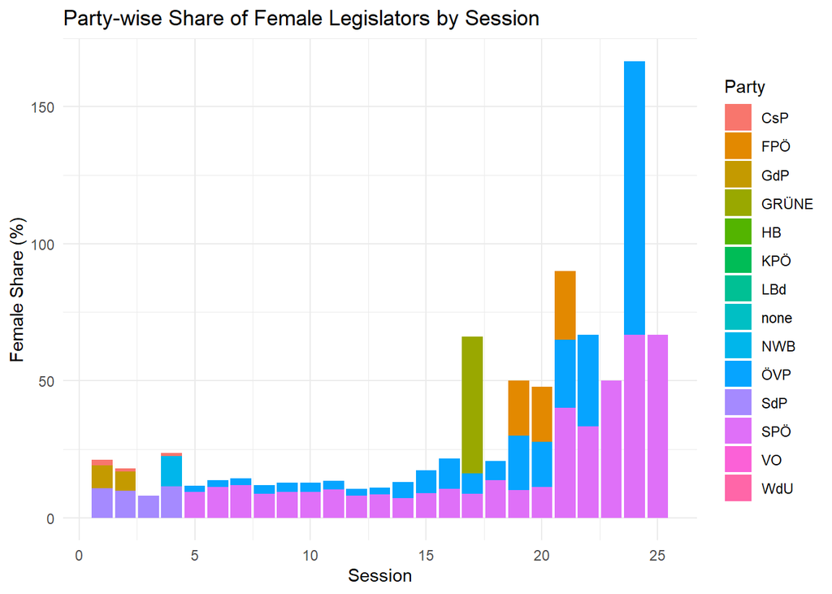

```r
#building on the question above, I am interested in looking at the party-wise share of female representation across the sessions

#we already have a merged dataset. Let's calculate party-wise share of female representation across the sessions as a new variable
female_share_by_session_party <- merged_aut %>%
  group_by(session, party) %>%
  summarize(female_share = mean(sex == "female", na.rm = TRUE) * 100) %>%
  arrange(session) #note: I used Google search to understand the combination of these three functions and saw an example of the same in stackoverflow


ggplot(female_share_by_session_party, aes(x = session, y = female_share, fill = party)) +
  geom_bar(stat = "identity", position = "stack") +
  labs(
    title = "Party-wise Share of Female Legislators by Session",
    x = "Session",
    y = "Female Share (%)",
    fill = "Party"
  ) +
  theme_minimal() +
  theme(legend.position = "right") #note: I used Google search to learn about this function and incorporated it here
```